# bank

Buthaina Alshareef

01-12-2020

#goal The classification goal is to predict if the client will subscribe a term deposit

#Attribute Information:

Input variables:

bank client data: 1 - age (numeric)

2 - job : type of job (categorical: ‘admin.’,‘blue-collar’,‘entrepreneur’,‘housemaid’,‘management’,‘retired’,‘self-employed’,‘services’,‘student’,‘technician’,‘unemployed’,‘unknown’)

3 - marital : marital status (categorical: ‘divorced’,‘married’,‘single’,‘unknown’; note: ‘divorced’ means divorced or widowed)

4 - education (categorical: ‘basic.4y’,‘basic.6y’,‘basic.9y’,‘high.school’,‘illiterate’,‘professional.course’,‘university.degree’,‘unknown’)

5 - default: has credit in default? (categorical: ‘no’,‘yes’,‘unknown’)

6 - housing: has housing loan? (categorical: ‘no’,‘yes’,‘unknown’)

7 - loan: has personal loan? (categorical: ‘no’,‘yes’,‘unknown’)

related with the last contact of the current campaign:

8 - contact: contact communication type (categorical: ‘cellular’,‘telephone’)

9 - month: last contact month of year (categorical: ‘jan’, ‘feb’, ‘mar’, …, ‘nov’, ‘dec’)

10 - day_of_week: last contact day of the week (categorical: ‘mon’,‘tue’,‘wed’,‘thu’,‘fri’)

11 - duration: last contact duration, in seconds (numeric). Important note: this attribute highly affects the output target (e.g., if duration=0 then y=‘no’). Yet, the duration is not known before a call is performed. Also, after the end of the call y is obviously known. Thus, this input should only be included for benchmark purposes and should be discarded if the intention is to have a realistic predictive model.

other attributes: 12 - campaign: number of contacts performed during this campaign and for this client (numeric, includes last contact)

13 - pdays: number of days that passed by after the client was last contacted from a previous campaign (numeric; 999 means client was not previously contacted)

14 - previous: number of contacts performed before this campaign and for this client (numeric)

15 - poutcome: outcome of the previous marketing campaign (categorical: ‘failure’,‘nonexistent’,‘success’)

social and economic context attributes:

16 - emp.var.rate: employment variation rate - quarterly indicator (numeric)

17 - cons.price.idx: consumer price index - monthly indicator (numeric)

18 - cons.conf.idx: consumer confidence index - monthly indicator (numeric)

19 - euribor3m: euribor 3 month rate - daily indicator (numeric)

20 - nr.employed: number of employees - quarterly indicator (numeric)

Output variable (desired target):

21 - y - has the client subscribed a term deposit? (binary: ‘yes’,‘no’)

```r
#http://archive.ics.uci.edu/ml/datasets/Bank+Marketing

#read the data set
bank <- read.csv2("data/bank-additional-full.csv", dec = ".")
```

convert all characters to factors

```r
bank[sapply(bank, is.character)] <- lapply(bank[sapply(bank, is.character)],
                                       as.factor)
```

#Portfolio Builder Exercise 1

EDA

```r
dim(bank)
```

```
## [1] 41188    21
```

```r
head(bank)
```

```
##   age       job marital   education default housing loan   contact month
## 1  56 housemaid married    basic.4y      no      no   no telephone   may
## 2  57  services married high.school unknown      no   no telephone   may
## 3  37  services married high.school      no     yes   no telephone   may
## 4  40    admin. married    basic.6y      no      no   no telephone   may
## 5  56  services married high.school      no      no  yes telephone   may
## 6  45  services married    basic.9y unknown      no   no telephone   may
##   day_of_week duration campaign pdays previous    poutcome emp.var.rate
## 1         mon      261        1   999        0 nonexistent          1.1
## 2         mon      149        1   999        0 nonexistent          1.1
## 3         mon      226        1   999        0 nonexistent          1.1
## 4         mon      151        1   999        0 nonexistent          1.1
## 5         mon      307        1   999        0 nonexistent          1.1
## 6         mon      198        1   999        0 nonexistent          1.1
##   cons.price.idx cons.conf.idx euribor3m nr.employed  y
## 1         93.994         -36.4     4.857        5191 no
## 2         93.994         -36.4     4.857        5191 no
## 3         93.994         -36.4     4.857        5191 no
## 4         93.994         -36.4     4.857        5191 no
## 5         93.994         -36.4     4.857        5191 no
## 6         93.994         -36.4     4.857        5191 no
```

```r
glimpse(bank)
```

```
## Rows: 41,188
## Columns: 21
## $ age            <int> 56, 57, 37, 40, 56, 45, 59, 41, 24, 25, 41, 25, 29, 57…
## $ job            <fct> housemaid, services, services, admin., services, servi…
## $ marital        <fct> married, married, married, married, married, married, …
## $ education      <fct> basic.4y, high.school, high.school, basic.6y, high.sch…
## $ default        <fct> no, unknown, no, no, no, unknown, no, unknown, no, no,…
## $ housing        <fct> no, no, yes, no, no, no, no, no, yes, yes, no, yes, no…
## $ loan           <fct> no, no, no, no, yes, no, no, no, no, no, no, no, yes, …
## $ contact        <fct> telephone, telephone, telephone, telephone, telephone,…
## $ month          <fct> may, may, may, may, may, may, may, may, may, may, may,…
## $ day_of_week    <fct> mon, mon, mon, mon, mon, mon, mon, mon, mon, mon, mon,…
## $ duration       <int> 261, 149, 226, 151, 307, 198, 139, 217, 380, 50, 55, 2…
## $ campaign       <int> 1, 1, 1, 1, 1, 1, 1, 1, 1, 1, 1, 1, 1, 1, 1, 1, 1, 1, …
## $ pdays          <int> 999, 999, 999, 999, 999, 999, 999, 999, 999, 999, 999,…
## $ previous       <int> 0, 0, 0, 0, 0, 0, 0, 0, 0, 0, 0, 0, 0, 0, 0, 0, 0, 0, …
## $ poutcome       <fct> nonexistent, nonexistent, nonexistent, nonexistent, no…
## $ emp.var.rate   <dbl> 1.1, 1.1, 1.1, 1.1, 1.1, 1.1, 1.1, 1.1, 1.1, 1.1, 1.1,…
## $ cons.price.idx <dbl> 93.994, 93.994, 93.994, 93.994, 93.994, 93.994, 93.994…
## $ cons.conf.idx  <dbl> -36.4, -36.4, -36.4, -36.4, -36.4, -36.4, -36.4, -36.4…
## $ euribor3m      <dbl> 4.857, 4.857, 4.857, 4.857, 4.857, 4.857, 4.857, 4.857…
## $ nr.employed    <dbl> 5191, 5191, 5191, 5191, 5191, 5191, 5191, 5191, 5191, …
## $ y              <fct> no, no, no, no, no, no, no, no, no, no, no, no, no, no…
```

descriptive statistics

```r
summary(bank)
```

```
##       age                 job            marital
##  Min.   :17.00   admin.     :10422   divorced: 4612
##  1st Qu.:32.00   blue-collar: 9254   married :24928
##  Median :38.00   technician : 6743   single  :11568
##  Mean   :40.02   services   : 3969   unknown :   80
##  3rd Qu.:47.00   management : 2924
##  Max.   :98.00   retired    : 1720
##                  (Other)    : 6156
##                education        default         housing           loan
##  university.degree  :12168   no     :32588   no     :18622   no     :33950
##  high.school        : 9515   unknown: 8597   unknown:  990   unknown:  990
##  basic.9y           : 6045   yes    :    3   yes    :21576   yes    : 6248
##  professional.course: 5243
##  basic.4y           : 4176
##  basic.6y           : 2292
##  (Other)            : 1749
##       contact          month       day_of_week    duration
##  cellular :26144   may    :13769   fri:7827    Min.   :   0.0
##  telephone:15044   jul    : 7174   mon:8514    1st Qu.: 102.0
##                    aug    : 6178   thu:8623    Median : 180.0
##                    jun    : 5318   tue:8090    Mean   : 258.3
##                    nov    : 4101   wed:8134    3rd Qu.: 319.0
##                    apr    : 2632               Max.   :4918.0
##                    (Other): 2016
##     campaign          pdays          previous            poutcome
##  Min.   : 1.000   Min.   :  0.0   Min.   :0.000   failure    : 4252
##  1st Qu.: 1.000   1st Qu.:999.0   1st Qu.:0.000   nonexistent:35563
##  Median : 2.000   Median :999.0   Median :0.000   success    : 1373
##  Mean   : 2.568   Mean   :962.5   Mean   :0.173
##  3rd Qu.: 3.000   3rd Qu.:999.0   3rd Qu.:0.000
##  Max.   :56.000   Max.   :999.0   Max.   :7.000
##
##   emp.var.rate      cons.price.idx  cons.conf.idx     euribor3m
##  Min.   :-3.40000   Min.   :92.20   Min.   :-50.8   Min.   :0.634
##  1st Qu.:-1.80000   1st Qu.:93.08   1st Qu.:-42.7   1st Qu.:1.344
##  Median : 1.10000   Median :93.75   Median :-41.8   Median :4.857
##  Mean   : 0.08189   Mean   :93.58   Mean   :-40.5   Mean   :3.621
##  3rd Qu.: 1.40000   3rd Qu.:93.99   3rd Qu.:-36.4   3rd Qu.:4.961
##  Max.   : 1.40000   Max.   :94.77   Max.   :-26.9   Max.   :5.045
##
##   nr.employed     y
##  Min.   :4964   no :36548
##  1st Qu.:5099   yes: 4640
##  Median :5191
##  Mean   :5167
##  3rd Qu.:5228
##  Max.   :5228
##
```

```r
typeof(bank)
```

```
## [1] "list"
```

```r
bank <- select(bank, -duration)
```

explore the distribution of categorical variables

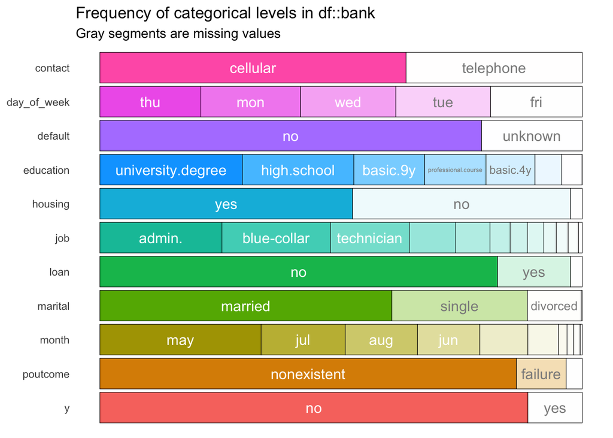

```r
ins <- inspect_cat(bank)
show_plot(ins)
```

##2 Assess the dataset for missingness.

```r
sum(is.na(bank))
```

```
## [1] 0
```

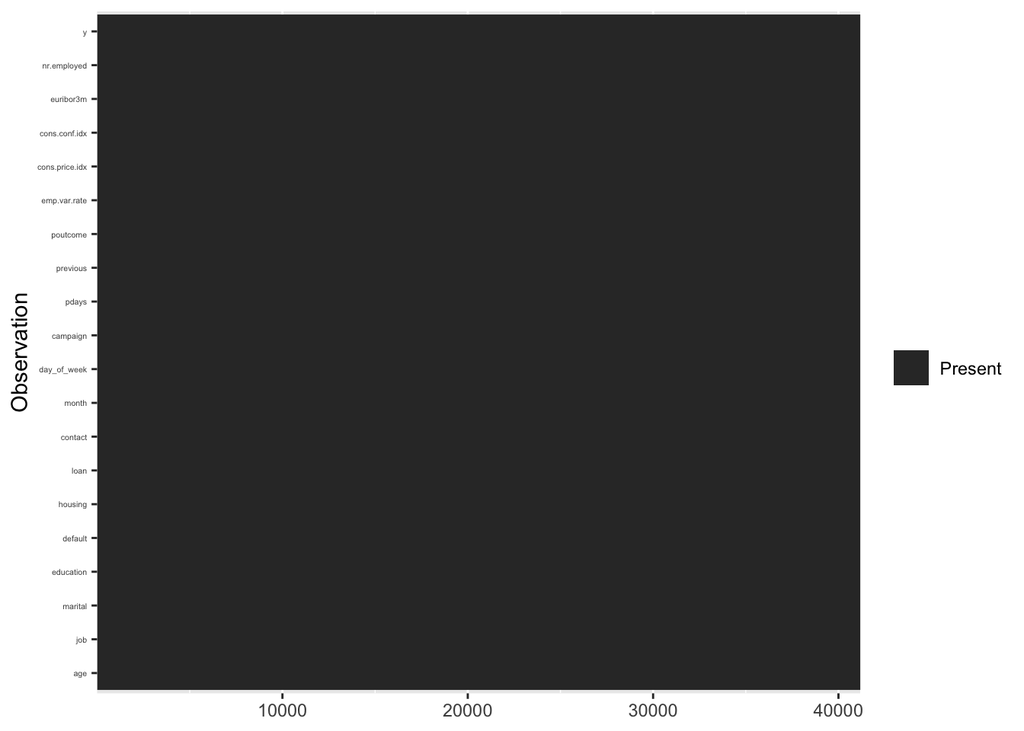

```r
bank %>%
  is.na() %>%
  reshape2::melt() %>%
  ggplot(aes(Var2, Var1, fill = value)) +
    geom_raster() +
    coord_flip() +
    scale_y_continuous(NULL, expand = c(0, 0)) +
    scale_fill_grey(name = "", labels = c("Present", "Missing")) +
    xlab("Observation") +
    theme(axis.text.y  = element_text(size = 4))
```

```r
bank <- select(bank, - nr.employed)
```

again assess the number of missing values

```r
sum(is.na(bank))
```

```
## [1] 0
```

there is no missing values!

check the target variable distribution

```r
prop.table(table(bank$y))
```

```
##
##        no       yes
## 0.8873458 0.1126542
```

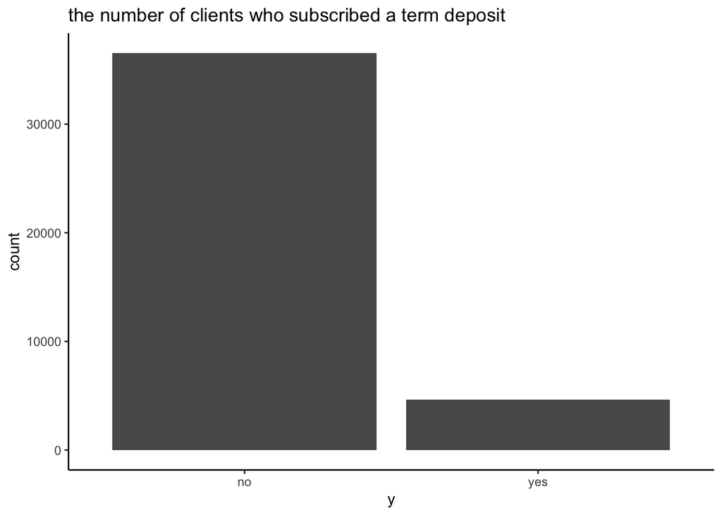

```r
ggplot(bank, aes(y)) +
   geom_bar() +
  labs(title = "the number of clients who subscribed a term deposit") +
  theme_classic()+
 NULL
```

Due to the imbalance in the classes we are going to split the data set into train and test with stratified sample

```r
set.seed(123) # for reproducibility
split <- initial_split(bank, strata = "y", prop = 0.7)
train <- training(split)
test  <- testing(split)
```

##3 Assess the variance across the features.

- Do any features have zero variance? no
- Do any features have near-zero variance? pdays

```r
caret::nearZeroVar(train, saveMetrics= TRUE) %>%
  rownames_to_column() %>%
  filter(nzv)
```

```
##   rowname freqRatio percentUnique zeroVar  nzv
## 1   pdays  84.38906    0.08670921   FALSE TRUE
```

##4 Assess the categorical features.

```r
count(train, job) %>% arrange(n)
```

```
##              job    n
## 1        unknown  233
## 2        student  596
## 3     unemployed  705
## 4      housemaid  711
## 5  self-employed  975
## 6   entrepreneur 1027
## 7        retired 1259
## 8     management 2029
## 9       services 2774
## 10    technician 4670
## 11   blue-collar 6489
## 12        admin. 7364
```

```r
count(train, education) %>% arrange(n)
```

```
##             education    n
## 1          illiterate   15
## 2             unknown 1194
## 3            basic.6y 1593
## 4            basic.4y 2905
## 5 professional.course 3616
## 6            basic.9y 4256
## 7         high.school 6736
## 8   university.degree 8517
```

##5 - Which values do you think should be one-hot or dummy encoded versus label encoded? Why? one-hot: all the categorical variables because many models require that all predictor variables be numeric.

```r
count(train, month)
```

```
##    month    n
## 1    apr 1877
## 2    aug 4315
## 3    dec  126
## 4    jul 4991
## 5    jun 3688
## 6    mar  390
## 7    may 9612
## 8    nov 2906
## 9    oct  506
## 10   sep  421
```

```r
count(train, day_of_week)
```

```
##   day_of_week    n
## 1         fri 5522
## 2         mon 5988
## 3         thu 5983
## 4         tue 5645
## 5         wed 5694
```

Execute a basic feature engineering process. First, apply a KNN model to your data without pre-applying feature engineering processes.

```r
cv <- trainControl(
  method = "repeatedcv",
  number = 10,
  repeats = 5,
  classProbs = TRUE,
  summaryFunction = twoClassSummary
  )

# 4. create a hyperparameter grid search
hyper_grid <- expand.grid(k = seq(2, 26, by = 2))
```

```r
knn_fit <- train(
  y ~ .,
  data = train,
  method = "knn",
  trControl = cv,
  tuneGrid = hyper_grid,
  metric = "ROC"
  )
```

```r
knn_fit
```

```
## k-Nearest Neighbors
##
## 28832 samples
##    18 predictor
##     2 classes: 'no', 'yes'
##
## No pre-processing
## Resampling: Cross-Validated (10 fold, repeated 5 times)
## Summary of sample sizes: 25949, 25949, 25948, 25948, 25949, 25949, ...
## Resampling results across tuning parameters:
##
##   k   ROC        Sens       Spec
##    2  0.6879975  0.9359756  0.3200746
##    4  0.7343087  0.9616636  0.2993850
##    6  0.7509653  0.9686211  0.2841104
##    8  0.7599569  0.9718653  0.2736399
##   10  0.7642713  0.9742261  0.2625595
##   12  0.7673538  0.9758756  0.2561538
##   14  0.7700371  0.9769466  0.2492579
##   16  0.7727540  0.9776814  0.2486422
##   18  0.7740591  0.9785569  0.2460541
##   20  0.7748928  0.9790964  0.2442703
##   22  0.7754197  0.9799563  0.2436541
##   24  0.7755157  0.9800344  0.2423007
##   26  0.7763127  0.9810194  0.2415614
##
## ROC was used to select the optimal model using the largest value.
## The final value used for the model was k = 26.
```

Create and a apply a blueprint of feature engineering processes that you think will help your model improve.

```r
blueprint <- recipe(y ~ ., data = train) %>%
  step_nzv(all_nominal()) %>%
  step_center(all_numeric(), -all_outcomes()) %>%
  step_scale(all_numeric(), -all_outcomes()) %>%
   step_dummy(all_nominal(), -all_outcomes(), one_hot = TRUE)
  #step_integer(all_nominal()) %>%
```

Now reapply the KNN model to your data that has been feature engineered.

```r
knn_fit_bp <- train(
  blueprint,
  data = train,
  method = "knn",
  trControl = cv,
  tuneGrid = hyper_grid,
  metric = "ROC"
  )
```

```r
knn_fit_bp
```

```
## k-Nearest Neighbors
##
## 28832 samples
##    18 predictor
##     2 classes: 'no', 'yes'
##
## Recipe steps: nzv, center, scale, dummy
## Resampling: Cross-Validated (10 fold, repeated 5 times)
## Summary of sample sizes: 25950, 25948, 25949, 25950, 25948, 25949, ...
## Resampling results across tuning parameters:
##
##   k   ROC        Sens       Spec
##    2  0.6782381  0.9184099  0.3256714
##    4  0.7187240  0.9597015  0.2988274
##    6  0.7360203  0.9683552  0.2849111
##    8  0.7470727  0.9716620  0.2809708
##   10  0.7529073  0.9742183  0.2737014
##   12  0.7572556  0.9762195  0.2708689
##   14  0.7605602  0.9778845  0.2668049
##   16  0.7637111  0.9793855  0.2626217
##   18  0.7662003  0.9801593  0.2584336
##   20  0.7660953  0.9810349  0.2557854
##   22  0.7678503  0.9818401  0.2540000
##   24  0.7690704  0.9825124  0.2502450
##   26  0.7709736  0.9827783  0.2495679
##
## ROC was used to select the optimal model using the largest value.
## The final value used for the model was k = 26.
```

Did your model performance improve?

```r
#save.image("myWorkspace_ex1.rds")
```

```r
#load("myWorkspace_ex1.rds")
```